# Projekt: Analiza ličnosti i njenih mračnih crta

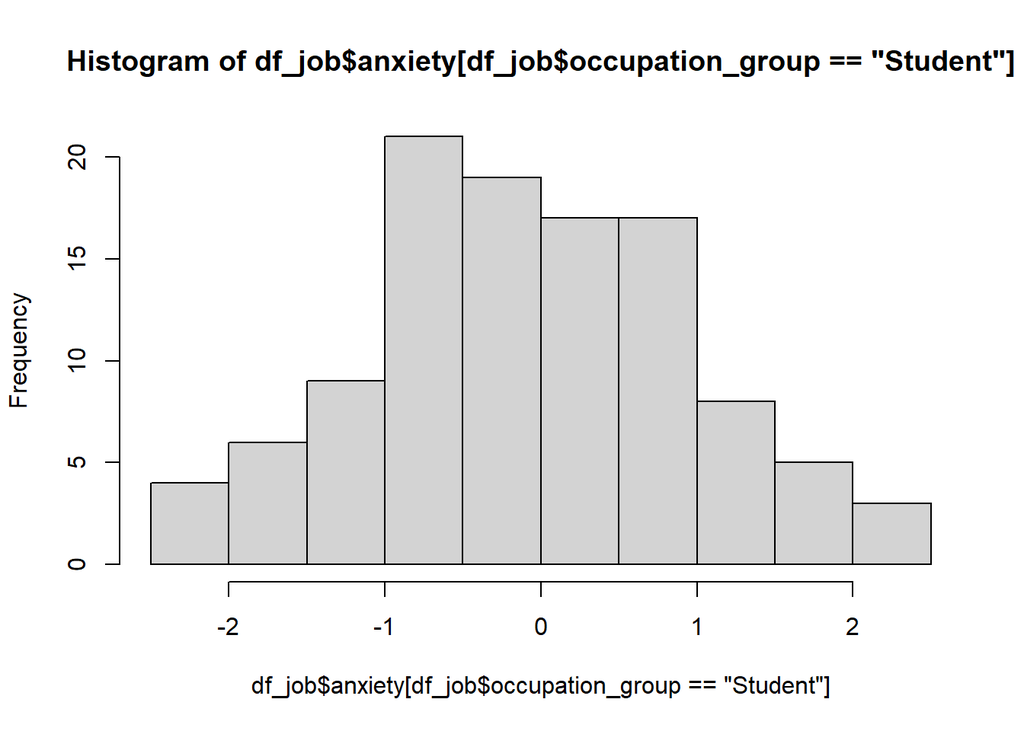

```r
hist(df_job$anxiety[df_job$occupation_group=='Student'])
```

```r
require(nortest)
lillie.test(df_job$anxiety)
```

```
##
##  Lilliefors (Kolmogorov-Smirnov) normality test
##
## data:  df_job$anxiety
## D = 0.040688, p-value = 0.1385
```

```r
lillie.test(df_job$anxiety[df_job$occupation_group=='Full-Time'])
```

```
##
##  Lilliefors (Kolmogorov-Smirnov) normality test
##
## data:  df_job$anxiety[df_job$occupation_group == "Full-Time"]
## D = 0.060222, p-value = 0.06789
```

```r
lillie.test(df_job$anxiety[df_job$occupation_group=='Part-Time'])
```

```
##
##  Lilliefors (Kolmogorov-Smirnov) normality test
##
## data:  df_job$anxiety[df_job$occupation_group == "Part-Time"]
## D = 0.15146, p-value = 0.03593
```

```r
lillie.test(df_job$anxiety[df_job$occupation_group=='Unemployed (and job seeking)'])
```

```
##
##  Lilliefors (Kolmogorov-Smirnov) normality test
##
## data:  df_job$anxiety[df_job$occupation_group == "Unemployed (and job seeking)"]
## D = 0.11293, p-value = 0.5953
```

```r
lillie.test(df_job$anxiety[df_job$occupation_group=='Student'])
```

```
##
##  Lilliefors (Kolmogorov-Smirnov) normality test
##
## data:  df_job$anxiety[df_job$occupation_group == "Student"]
## D = 0.042081, p-value = 0.9066
```

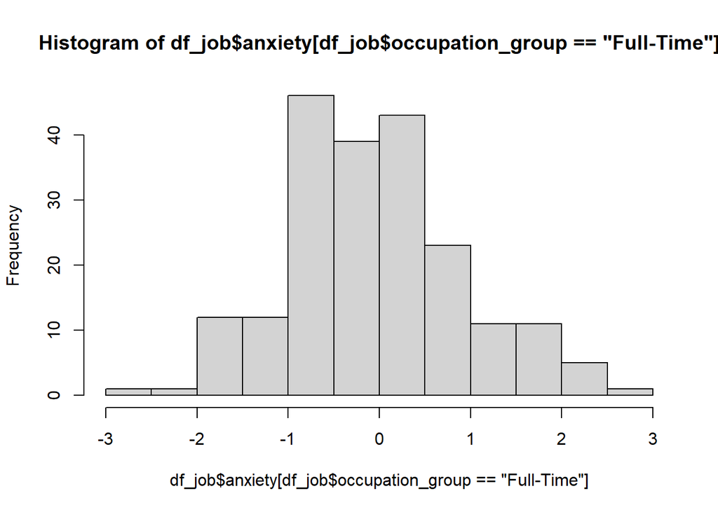

```r
hist(df_job$anxiety[df_job$occupation_group=='Full-Time'])
```

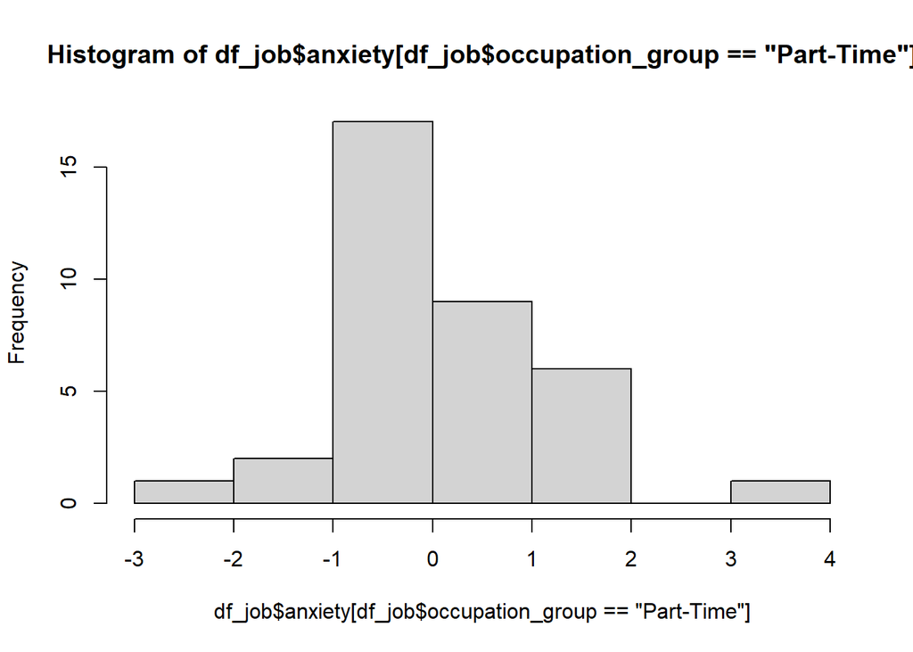

```r
hist(df_job$anxiety[df_job$occupation_group=='Part-Time'])
```

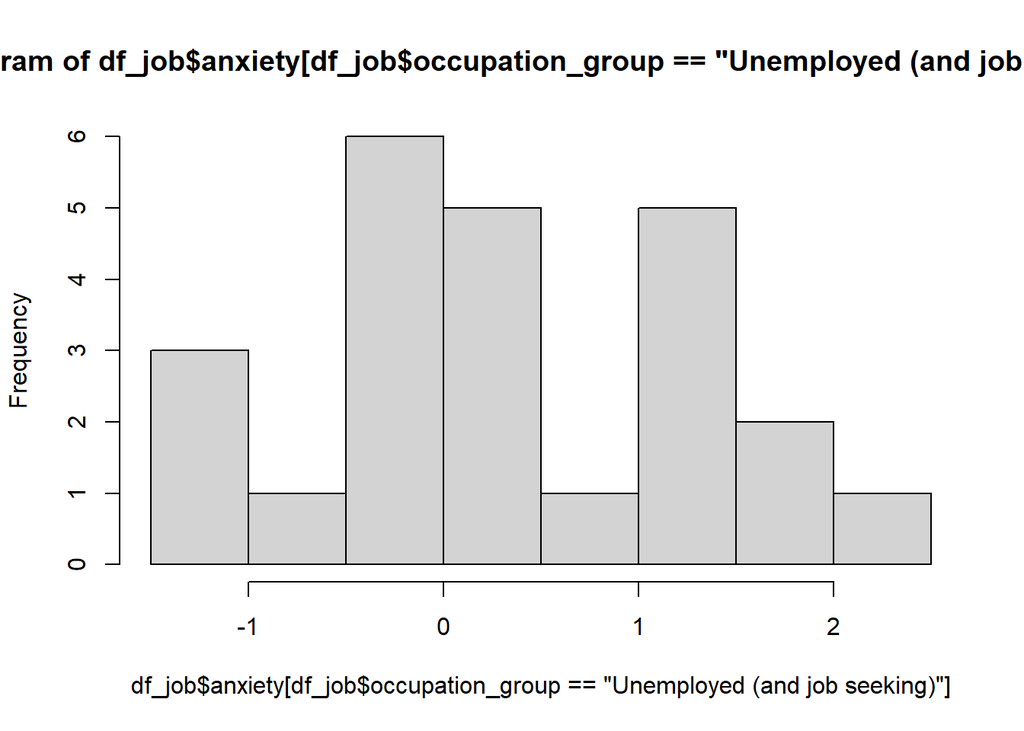

```r
hist(df_job$anxiety[df_job$occupation_group=='Unemployed (and job seeking)'])
```

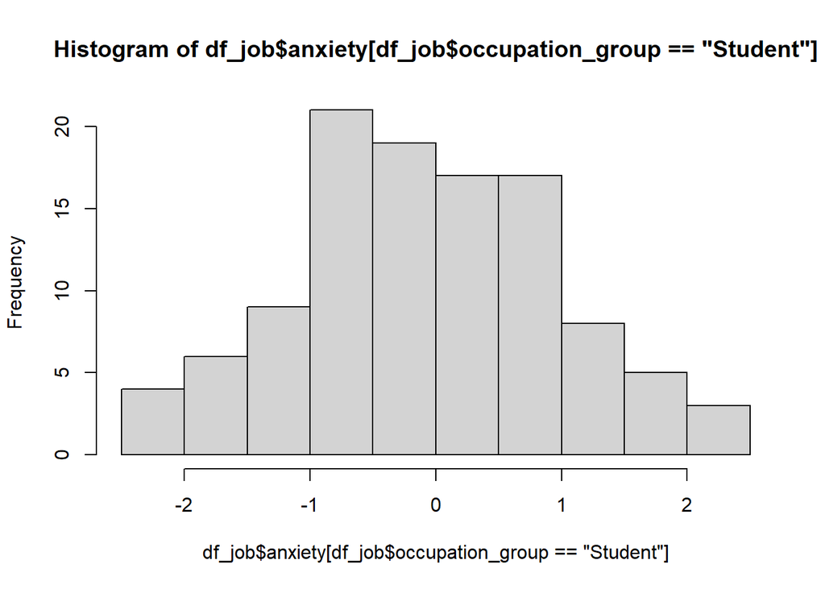

```r
hist(df_job$anxiety[df_job$occupation_group=='Student'])
```

Test pretpostavki normalnosti za stres

```r
require(nortest)
lillie.test(df_job$stress)
```

```
##
##  Lilliefors (Kolmogorov-Smirnov) normality test
##
## data:  df_job$stress
## D = 0.038095, p-value = 0.2075
```

```r
lillie.test(df_job$stress[df_job$occupation_group=='Full-Time'])
```

```
##
##  Lilliefors (Kolmogorov-Smirnov) normality test
##
## data:  df_job$stress[df_job$occupation_group == "Full-Time"]
## D = 0.057729, p-value = 0.09354
```

```r
lillie.test(df_job$stress[df_job$occupation_group=='Part-Time'])
```

```
##
##  Lilliefors (Kolmogorov-Smirnov) normality test
##
## data:  df_job$stress[df_job$occupation_group == "Part-Time"]
## D = 0.091433, p-value = 0.6263
```

```r
lillie.test(df_job$stress[df_job$occupation_group=='Unemployed (and job seeking)'])
```

```
##
##  Lilliefors (Kolmogorov-Smirnov) normality test
##
## data:  df_job$stress[df_job$occupation_group == "Unemployed (and job seeking)"]
## D = 0.070023, p-value = 0.9916
```

```r
lillie.test(df_job$stress[df_job$occupation_group=='Student'])
```

```
##
##  Lilliefors (Kolmogorov-Smirnov) normality test
##
## data:  df_job$stress[df_job$occupation_group == "Student"]
## D = 0.062087, p-value = 0.3808
```

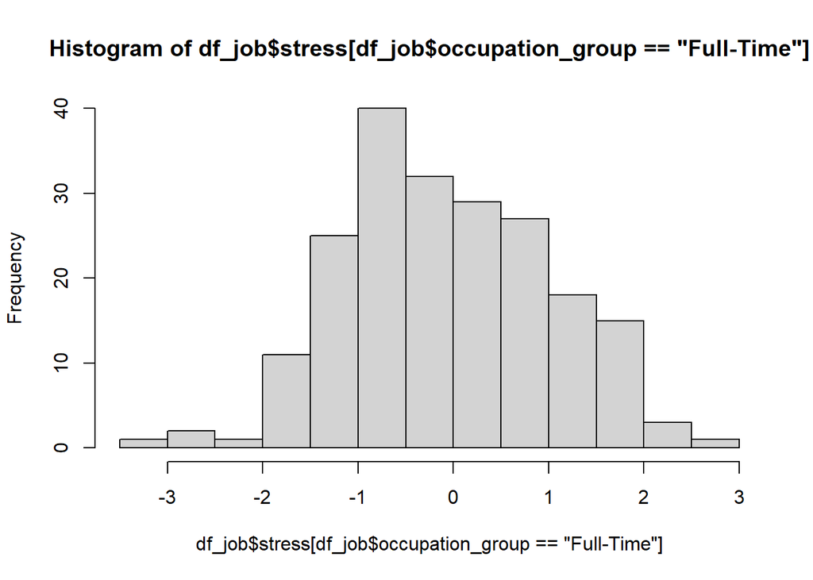

```r
hist(df_job$stress[df_job$occupation_group=='Full-Time'])
```

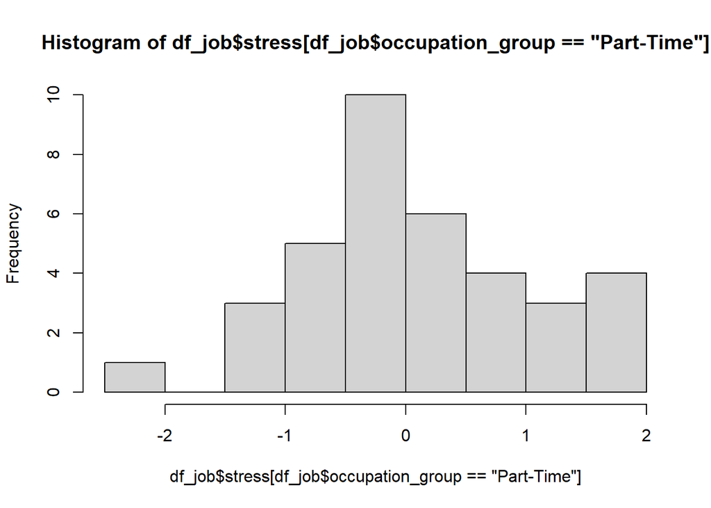

```r
hist(df_job$stress[df_job$occupation_group=='Part-Time'])
```

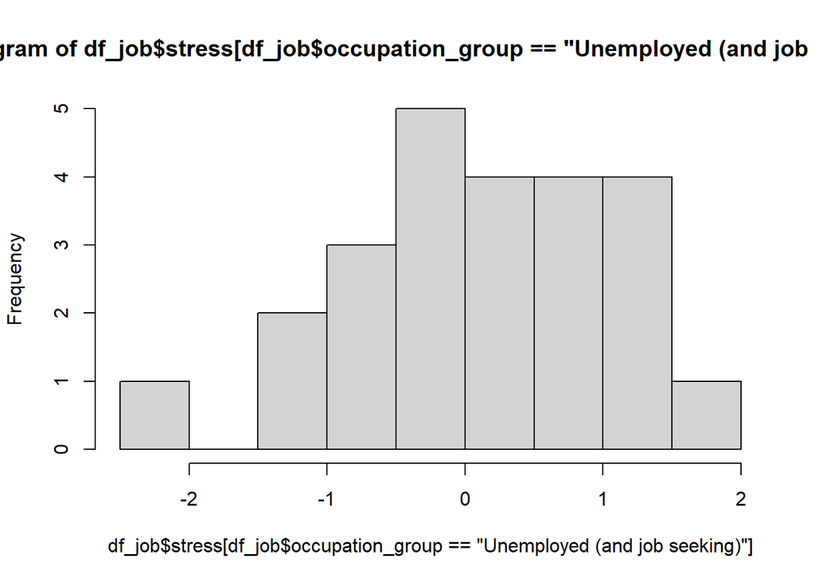

```r
hist(df_job$stress[df_job$occupation_group=='Unemployed (and job seeking)'])
```

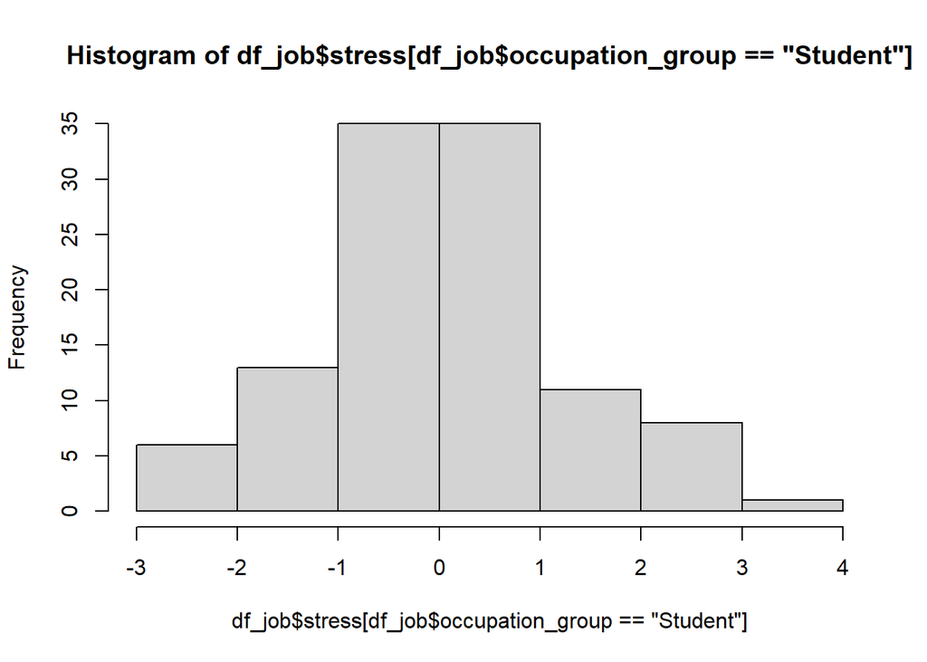

```r
hist(df_job$stress[df_job$occupation_group=='Student'])
```

Test pretpostavki homogenosti varijanci za anksioznost

```r
bartlett.test(df_job$anxiety ~ df_job$occupation_group)
```

```
##
##  Bartlett test of homogeneity of variances
##
## data:  df_job$anxiety by df_job$occupation_group
## Bartlett's K-squared = 1.0818, df = 3, p-value = 0.7815
```

```r
var((df_job$anxiety[df_job$occupation_group=='Full-Time']))
```

```
## [1] 0.9497347
```

```r
var((df_job$anxiety[df_job$occupation_group=='Part-Time']))
```

```
## [1] 1.159903
```

```r
var((df_job$anxiety[df_job$occupation_group=='Unemployed (and job seeking)']))
```

```
## [1] 1.070241
```

```r
var((df_job$anxiety[df_job$occupation_group=='Student']))
```

```
## [1] 1.091825
```

Test pretpostavki homogenosti varijanci za depresiju

```r
bartlett.test(df_job$depression ~ df_job$occupation_group)
```

```
##
##  Bartlett test of homogeneity of variances
##
## data:  df_job$depression by df_job$occupation_group
## Bartlett's K-squared = 0.78061, df = 3, p-value = 0.8541
```

```r
var((df_job$depression[df_job$occupation_group=='Full-Time']))
```

```
## [1] 1.200926
```

```r
var((df_job$depression[df_job$occupation_group=='Part-Time']))
```

```
## [1] 1.220683
```

```r
var((df_job$depression[df_job$occupation_group=='Unemployed (and job seeking)']))
```

```
## [1] 0.9148913
```

```r
var((df_job$depression[df_job$occupation_group=='Student']))
```

```
## [1] 1.222059
```

Test pretpostavki homogenosti varijanci za stres

```r
bartlett.test(df_job$stress ~ df_job$occupation_group)
```

```
##
##  Bartlett test of homogeneity of variances
##
## data:  df_job$stress by df_job$occupation_group
## Bartlett's K-squared = 3.3471, df = 3, p-value = 0.3411
```

```r
var((df_job$stress[df_job$occupation_group=='Full-Time']))
```

```
## [1] 1.14987
```

```r
var((df_job$stress[df_job$occupation_group=='Part-Time']))
```

```
## [1] 0.8855903
```

```r
var((df_job$stress[df_job$occupation_group=='Unemployed (and job seeking)']))
```

```
## [1] 1.022324
```

```r
var((df_job$stress[df_job$occupation_group=='Student']))
```

```
## [1] 1.408198
```

```r
summary(aov(anxiety ~ occupation_group, data = df_job))
```

```
##                   Df Sum Sq Mean Sq F value Pr(>F)
## occupation_group   3    4.0   1.339   1.314  0.269
## Residuals        370  376.9   1.019
```

```r
summary(aov(depression ~ occupation_group, data = df_job))
```

```
##                   Df Sum Sq Mean Sq F value Pr(>F)
## occupation_group   3    8.3   2.781   2.334 0.0736 .
## Residuals        370  440.7   1.191
## ---
## Signif. codes:  0 '***' 0.001 '**' 0.01 '*' 0.05 '.' 0.1 ' ' 1
```

```r
summary(aov(stress ~ occupation_group, data = df_job))
```

```
##                   Df Sum Sq Mean Sq F value Pr(>F)
## occupation_group   3    2.2   0.732   0.614  0.606
## Residuals        370  441.2   1.192
```

Provedene su jednosmjerne analize varijance (ANOVA) s ciljem ispitivanja razlika u razini anksioznosti, depresije i stresa između skupina definiranih prema zanimanju.

Rezultati pokazuju da ne postoje statistički značajne razlike u razini anksioznosti među zanimanjima, F(3, 370) = 1.31, p = 0.269. Također, nisu utvrđene statistički značajne razlike u razini stresa, F(3, 370) = 0.61, p = 0.606.

Za depresiju je uočen trend prema razlikama između skupina, no rezultat nije dosegnuo konvencionalnu razinu statističke značajnosti, F(3, 370) = 2.33, p = 0.0736. Dobiveni nalazi upućuju na to da zanimanje samo po sebi nije snažan prediktor razine mentalnog zdravlja u ovom uzorku.

## Provođenje višestruke regresije za pokazivanje doprinosa zanimanja anksioznosti povrh ličnosti

```r
model_anxiety <- lm(
  anxiety ~ occupation_group +
  narcissism + machiavelism + psychoticism + sadism + neuroticism +
  extraversion + openness + agreeableness + conscientiousness,
  data = df_job
)

summary(model_anxiety)
```

```
##
## Call:
## lm(formula = anxiety ~ occupation_group + narcissism + machiavelism +
##     psychoticism + sadism + neuroticism + extraversion + openness +
##     agreeableness + conscientiousness, data = df_job)
##
## Residuals:
##     Min      1Q  Median      3Q     Max
## -2.8777 -0.5030  0.0377  0.5391  3.2731
##
## Coefficients:
##                                               Estimate Std. Error t value
## (Intercept)                                   0.010784   0.064791   0.166
## occupation_groupPart-Time                     0.171681   0.168508   1.019
## occupation_groupStudent                      -0.110070   0.110430  -0.997
## occupation_groupUnemployed (and job seeking)  0.048740   0.210452   0.232
## narcissism                                   -0.066293   0.063274  -1.048
## machiavelism                                  0.089268   0.058164   1.535
## psychoticism                                  0.069755   0.068022   1.025
## sadism                                        0.070111   0.063485   1.104
## neuroticism                                   0.372737   0.064679   5.763
## extraversion                                  0.117466   0.068659   1.711
## openness                                      0.066920   0.050444   1.327
## agreeableness                                -0.035415   0.064335  -0.550
## conscientiousness                            -0.007022   0.064727  -0.108
##                                              Pr(>|t|)
## (Intercept)                                     0.868
## occupation_groupPart-Time                       0.309
## occupation_groupStudent                         0.320
## occupation_groupUnemployed (and job seeking)    0.817
## narcissism                                      0.295
## machiavelism                                    0.126
## psychoticism                                    0.306
## sadism                                          0.270
## neuroticism                                  1.77e-08 ***
## extraversion                                    0.088 .
## openness                                        0.185
## agreeableness                                   0.582
## conscientiousness                               0.914
## ---
## Signif. codes:  0 '***' 0.001 '**' 0.01 '*' 0.05 '.' 0.1 ' ' 1
##
## Residual standard error: 0.9153 on 361 degrees of freedom
## Multiple R-squared:  0.2061, Adjusted R-squared:  0.1797
## F-statistic: 7.807 on 12 and 361 DF,  p-value: 5.873e-13
```

U svrhu ispitivanja odnosa između zanimanja i anksioznosti, proveden je model višestruke linearne regresije kojim se ispituje doprinos radnog statusa povrh crta ličnosti.

Rezultati pokazuju da je model statistički značajan u cjelini (F(12, 361) = 7.807, p = 5.873x$10^{-13}$), pri čemu Multiple R-squared iznosi 0.2061, a Adjusted R-squared 0.1797. Iako je objašnjeni udio varijance manji u odnosu na modele za stres i depresiju, vrijednosti upućuju na to da model ipak ima smisla za interpretaciju.

Analizom mračnih crta ličnosti nije utvrđen nijedan statistički značajan prediktor anksioznosti. Narcizam, makijavelizam, psihoticizam i sadizam nisu pokazali jedinstveni doprinos u ovom modelu, što sugerira da se njihova povezanost s anksioznošću ne zadržava nakon uključivanja ostalih crta ličnosti.

Unutar petofaktorskog modela ličnosti, neuroticizam se jasno istaknuo kao ključni prediktor anksioznosti ($\beta$ = 0.372737, p = 1.77x$10^{-8}$). Osobe s višim razinama neuroticizma pokazuju izraženiju anksioznost, neovisno o zanimanju i ostalim osobinama ličnosti, što je u skladu s postojećim teorijskim i empirijskim nalazima. Ekstraverzija nije dosegnula razinu statističke značajnosti ($\beta$ = 0.117466, p = 0.088), no uočen je slab trend koji upućuje na višu razinu anksioznosti kod ekstravertiranijih osoba. Ostale Big Five crte nisu se pokazale značajnima u ovom modelu.

## Provođenje višestruke regresije za pokazivanje doprinosa zanimanja depresiji povrh ličnosti

```r
model_depression <- lm(
  depression ~ occupation_group +
  narcissism + machiavelism + psychoticism + sadism + neuroticism +
  extraversion + openness + agreeableness + conscientiousness,
  data = df_job
)

summary(model_depression)
```

```
##
## Call:
## lm(formula = depression ~ occupation_group + narcissism + machiavelism +
##     psychoticism + sadism + neuroticism + extraversion + openness +
##     agreeableness + conscientiousness, data = df_job)
##
## Residuals:
##      Min       1Q   Median       3Q      Max
## -3.02110 -0.46296  0.03503  0.47615  2.57324
##
## Coefficients:
##                                               Estimate Std. Error t value
## (Intercept)                                   0.056563   0.057575   0.982
## occupation_groupPart-Time                    -0.002998   0.149741  -0.020
## occupation_groupStudent                      -0.035153   0.098132  -0.358
## occupation_groupUnemployed (and job seeking) -0.181134   0.187013  -0.969
## narcissism                                   -0.027405   0.056227  -0.487
## machiavelism                                  0.088226   0.051687   1.707
## psychoticism                                  0.129060   0.060446   2.135
## sadism                                        0.015564   0.056414   0.276
## neuroticism                                   0.439192   0.057476   7.641
## extraversion                                 -0.302426   0.061012  -4.957
## openness                                      0.031826   0.044826   0.710
## agreeableness                                 0.056346   0.057170   0.986
## conscientiousness                            -0.018329   0.057518  -0.319
##                                              Pr(>|t|)
## (Intercept)                                    0.3266
## occupation_groupPart-Time                      0.9840
## occupation_groupStudent                        0.7204
## occupation_groupUnemployed (and job seeking)   0.3334
## narcissism                                     0.6263
## machiavelism                                   0.0887 .
## psychoticism                                   0.0334 *
## sadism                                         0.7828
## neuroticism                                  1.96e-13 ***
## extraversion                                 1.10e-06 ***
## openness                                       0.4782
## agreeableness                                  0.3250
## conscientiousness                              0.7502
## ---
## Signif. codes:  0 '***' 0.001 '**' 0.01 '*' 0.05 '.' 0.1 ' ' 1
##
## Residual standard error: 0.8133 on 361 degrees of freedom
## Multiple R-squared:  0.4682, Adjusted R-squared:  0.4506
## F-statistic: 26.49 on 12 and 361 DF,  p-value: < 2.2e-16
```

Kako bi se ispitao doprinos zanimanja depresiji uz kontrolu crta ličnosti, proveden je model višestruke linearne regresije.

Model se pokazao izrazito snažnim u objašnjenju ishoda, s vrijednostima F(12, 361) = 26.49 i p = 2.2x$10^{-16}$. Multiple R-squared iznosi 0.4682, dok Adjusted R-squared iznosi 0.4506, što upućuje na to da model objašnjava velik dio varijance depresije te ima vrlo dobru objašnjavajuću snagu.

Unutar petofaktorskog modela, neuroticizam se ponovno istaknuo kao najsnažniji pozitivni prediktor depresije ($\beta$ = 0.439192, p = 1.96x$10^{-13}$), potvrđujući njegovu ključnu ulogu u objašnjenju emocionalnih poteškoća. Za razliku od modela za stres i anksioznost, ekstraverzija se ovdje pokazala statistički značajnim negativnim prediktorom ($\beta$ = -0.302426, p = 1.10x$10^{-6}$), što upućuje na to da osobe s višom razinom ekstraverzije pokazuju nižu razinu depresije. Ostale crte Big Five modela nisu se pokazale značajnima.

```r
model_stress <- lm(
  stress ~ occupation_group +
  narcissism + machiavelism + psychoticism + sadism + neuroticism +
  extraversion + openness + agreeableness + conscientiousness,
  data = df_job
)

summary(model_stress)
```

```
##
## Call:
## lm(formula = stress ~ occupation_group + narcissism + machiavelism +
##     psychoticism + sadism + neuroticism + extraversion + openness +
##     agreeableness + conscientiousness, data = df_job)
##
## Residuals:
##     Min      1Q  Median      3Q     Max
## -3.0898 -0.5186  0.0879  0.5882  3.2164
##
## Coefficients:
##                                               Estimate Std. Error t value
## (Intercept)                                   0.006104   0.065465   0.093
## occupation_groupPart-Time                     0.089980   0.170263   0.528
## occupation_groupStudent                       0.046961   0.111580   0.421
## occupation_groupUnemployed (and job seeking) -0.362641   0.212643  -1.705
## narcissism                                   -0.012195   0.063933  -0.191
## machiavelism                                  0.112090   0.058770   1.907
## psychoticism                                  0.204240   0.068730   2.972
## sadism                                       -0.029011   0.064146  -0.452
## neuroticism                                   0.406136   0.065353   6.215
## extraversion                                 -0.084191   0.069374  -1.214
## openness                                      0.142228   0.050970   2.790
## agreeableness                                -0.048592   0.065005  -0.748
## conscientiousness                             0.004554   0.065401   0.070
##                                              Pr(>|t|)
## (Intercept)                                   0.92576
## occupation_groupPart-Time                     0.59749
## occupation_groupStudent                       0.67410
## occupation_groupUnemployed (and job seeking)  0.08898 .
## narcissism                                    0.84883
## machiavelism                                  0.05728 .
## psychoticism                                  0.00316 **
## sadism                                        0.65135
## neuroticism                                  1.42e-09 ***
## extraversion                                  0.22570
## openness                                      0.00554 **
## agreeableness                                 0.45525
## conscientiousness                             0.94453
## ---
## Signif. codes:  0 '***' 0.001 '**' 0.01 '*' 0.05 '.' 0.1 ' ' 1
##
## Residual standard error: 0.9248 on 361 degrees of freedom
## Multiple R-squared:  0.3036, Adjusted R-squared:  0.2805
## F-statistic: 13.12 on 12 and 361 DF,  p-value: < 2.2e-16
```

Iz modela višestruke linearne regresije koji izračunava doprinos zanimanja stresu povrh ličnosti zaključujemo sljedeće stvari.

Model se pokazuje statistički značajnim u cjelini s vrijednostima F(12, 361) = 13.12 i p = 2.2x$10^{-16}$ (< 0.001) te je Multiple R-squared = 0.3036 i Adjusted R-squared = 0.2805. Ove vrijednosti upućuju da model ima dobru potpornu (objašnjavajuću) snagu.

Među mračnim crtama ličnosti, psihoticizam se istaknuo kao statistički značajan pozitivan prediktor ($\beta$ = 0.204240, p = 0.00316 (< 0.01)). To znači da osobe s višim razinama psihoticizma pokazuju višu razinu stresa, čak i nakon utjecaja ostalih crta ličnosti i oblika radnog angažmana. Makijavelizam je pokazao trend prema pozitivnoj povezanosti ($/beta$ = 0.112090, p = 0.05728 (< 0.1)), ali rezultati su nedovoljni za snažnu povezanost. Narcizam i sadizam nisu pokazali značajan doprinos.

Unutar petofaktorskog Big 5 modela, neurocitizam se pokazao daleko najsnažnijim prediktorom ishoda ($\beta$ = 0.406136, p = 1.42x$10^{-9}$ (< 0.001)). Viša razina neurocitizma povezana je s višom razinom stresa, neovisno o radnom odnosu i ostalim crtama ličnosti. Ovaj rezultat je u potpunosti u skladu s teorijskim očekivanjima. Izdvajamo i otvorenost kao statistički značajan pozititvan prediktor ($\beta$ = 0.142228, p = 0.00554 (< 0.01). Ovaj podatak sugerira da osobe s više otvorenosti mogu biti osjetljivije na stres. Ekstraverzija, ugodnost i savjesnost nisu pokazale statistički značajan u ovom modelu.